# Lab1_Assignment(Updated)

Lab1: Report

Objective: Task 1: Logistic Regression using single feature Task 2: Logistic Regression using multiple features

Submitted by: Sulav Karki ACE079BCT070

Machine Learning: Machine Learning(ML) is the brach of computer science that allows a computer to learn from a dataset and improve the overall performance of themselves without being programmed/improved by the programmer.

Types of Machine Learning:

1. Supervised Learning: Supervised Learning in ML refers to the process through which a computer/system learns from labeled data i.e data having both input and output.  
   An example is Email Spam Detection.
2. Unsupervised Learning: Unsupervised Learning in ML refers to the process through which a computer/system learns from unlabled data i.e data having only inputs and no outputs. Such learning aims to discovering hidden patterns or structures in the data without knowing the correct answer. An exaple is Customer Segmentation System

The ML pipeline has the following components:

1. Data Retrieval and Collection
2. Data Cleaning
3. Feature Design
4. Algorithm Selection
5. Loss Function Selection
6. Model Learning
7. Model Evaluation

Task 1:

```python
import pandas as pd
import numpy as np
import matplotlib.pyplot as plt
from sklearn.model_selection import train_test_split
from sklearn.preprocessing import StandardScaler
from sklearn.linear_model import LogisticRegression
from sklearn.metrics import accuracy_score, confusion_matrix, classification_report

df = pd.read_csv("E:/Sulav/Program/AI lab/Lab1_Assignment/Heart_Disease_Prediction.csv")

df.head()
```

|  | Age | Sex | Chest pain type | BP | Cholesterol | FBS over 120 | EKG results | Max HR | Exercise angina | ST depression | Slope of ST | Number of vessels fluro | Thallium | Heart Disease |
| --- | --- | --- | --- | --- | --- | --- | --- | --- | --- | --- | --- | --- | --- | --- |
| 0 | 70 | 1 | 4 | 130 | 322 | 0 | 2 | 109 | 0 | 2.4 | 2 | 3 | 3 | Presence |
| 1 | 67 | 0 | 3 | 115 | 564 | 0 | 2 | 160 | 0 | 1.6 | 2 | 0 | 7 | Absence |
| 2 | 57 | 1 | 2 | 124 | 261 | 0 | 0 | 141 | 0 | 0.3 | 1 | 0 | 7 | Presence |
| 3 | 64 | 1 | 4 | 128 | 263 | 0 | 0 | 105 | 1 | 0.2 | 2 | 1 | 7 | Absence |
| 4 | 74 | 0 | 2 | 120 | 269 | 0 | 2 | 121 | 1 | 0.2 | 1 | 1 | 3 | Absence |

```python
df['Heart Disease'].unique()
```

```
array(['Presence', 'Absence'], dtype=object)
```

```python
df.isnull().sum()
```

```
Age                        0
Sex                        0
Chest pain type            0
BP                         0
Cholesterol                0
FBS over 120               0
EKG results                0
Max HR                     0
Exercise angina            0
ST depression              0
Slope of ST                0
Number of vessels fluro    0
Thallium                   0
Heart Disease              0
dtype: int64
```

```python
df['Heart Disease']=df['Heart Disease'].map({'Presence': 1, 'Absence': 0})
```

```python
df.head()
```

|  | Age | Sex | Chest pain type | BP | Cholesterol | FBS over 120 | EKG results | Max HR | Exercise angina | ST depression | Slope of ST | Number of vessels fluro | Thallium | Heart Disease |
| --- | --- | --- | --- | --- | --- | --- | --- | --- | --- | --- | --- | --- | --- | --- |
| 0 | 70 | 1 | 4 | 130 | 322 | 0 | 2 | 109 | 0 | 2.4 | 2 | 3 | 3 | 1 |
| 1 | 67 | 0 | 3 | 115 | 564 | 0 | 2 | 160 | 0 | 1.6 | 2 | 0 | 7 | 0 |
| 2 | 57 | 1 | 2 | 124 | 261 | 0 | 0 | 141 | 0 | 0.3 | 1 | 0 | 7 | 1 |
| 3 | 64 | 1 | 4 | 128 | 263 | 0 | 0 | 105 | 1 | 0.2 | 2 | 1 | 7 | 0 |
| 4 | 74 | 0 | 2 | 120 | 269 | 0 | 2 | 121 | 1 | 0.2 | 1 | 1 | 3 | 0 |

```python
X = df[["Cholesterol"]].values
y = df["Heart Disease"].values
```

```python
X_train, X_test, y_train, y_test = train_test_split(
    X, y, test_size=0.33, random_state=42
)
```

```python
scaler = StandardScaler()
X_train = scaler.fit_transform(X_train)
X_test = scaler.transform(X_test)
```

```python
model = LogisticRegression()
model.fit(X_train, y_train)
```

```
LogisticRegression()
```

```python
y_pred = model.predict(X_test)
```

```python
print("Accuracy:", accuracy_score(y_test, y_pred))
print("\nConfusion Matrix:\n", confusion_matrix(y_test, y_pred))
print("\nClassification Report:\n", classification_report(y_test, y_pred))
```

```
Accuracy: 0.6

Confusion Matrix:
 [[54  0]
 [36  0]]

Classification Report:
               precision    recall  f1-score   support

           0       0.60      1.00      0.75        54
           1       0.00      0.00      0.00        36

    accuracy                           0.60        90
   macro avg       0.30      0.50      0.38        90
weighted avg       0.36      0.60      0.45        90
```

[output not shown]

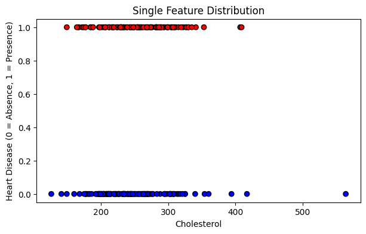

```python
plt.figure(figsize=(7,4))
plt.scatter(X, y, c=y, cmap='bwr', edgecolor='k')
plt.xlabel("Cholesterol")
plt.ylabel("Heart Disease (0 = Absence, 1 = Presence)")
plt.title("Single Feature Distribution")
plt.show()
```

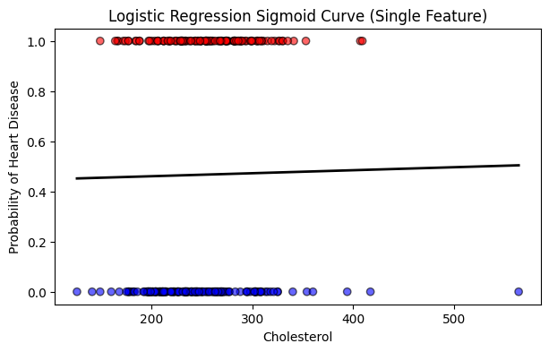

```python
X_range = np.linspace(X.min(), X.max(), 300).reshape(-1, 1)
X_range_scaled = scaler.transform(X_range)
y_prob = model.predict_proba(X_range_scaled)[:, 1]
plt.figure(figsize=(7,4))
plt.scatter(X, y, c=y, cmap='bwr', edgecolor='k', alpha=0.6)
plt.plot(X_range, y_prob, color='black', linewidth=2)
plt.xlabel("Cholesterol")
plt.ylabel("Probability of Heart Disease")
plt.title("Logistic Regression Sigmoid Curve (Single Feature)")
plt.show()
```

```python
df = pd.read_csv("E:/Sulav/Program/AI lab/Lab1_Assignment/Heart_Disease_Prediction.csv")
```

```python
df.head()
```

|  | Age | Sex | Chest pain type | BP | Cholesterol | FBS over 120 | EKG results | Max HR | Exercise angina | ST depression | Slope of ST | Number of vessels fluro | Thallium | Heart Disease |
| --- | --- | --- | --- | --- | --- | --- | --- | --- | --- | --- | --- | --- | --- | --- |
| 0 | 70 | 1 | 4 | 130 | 322 | 0 | 2 | 109 | 0 | 2.4 | 2 | 3 | 3 | Presence |
| 1 | 67 | 0 | 3 | 115 | 564 | 0 | 2 | 160 | 0 | 1.6 | 2 | 0 | 7 | Absence |
| 2 | 57 | 1 | 2 | 124 | 261 | 0 | 0 | 141 | 0 | 0.3 | 1 | 0 | 7 | Presence |
| 3 | 64 | 1 | 4 | 128 | 263 | 0 | 0 | 105 | 1 | 0.2 | 2 | 1 | 7 | Absence |
| 4 | 74 | 0 | 2 | 120 | 269 | 0 | 2 | 121 | 1 | 0.2 | 1 | 1 | 3 | Absence |

```python
df.isnull().sum()
```

```
Age                        0
Sex                        0
Chest pain type            0
BP                         0
Cholesterol                0
FBS over 120               0
EKG results                0
Max HR                     0
Exercise angina            0
ST depression              0
Slope of ST                0
Number of vessels fluro    0
Thallium                   0
Heart Disease              0
dtype: int64
```

```python
df["Heart Disease"] = df["Heart Disease"].map({"Presence": 1, "Absence": 0})
```

```python
X = df.drop("Heart Disease", axis=1).values
y = df["Heart Disease"].values
```

```python
X_train, X_test, y_train, y_test = train_test_split(
    X, y, test_size=0.33, random_state=42, stratify=y
)
```

```python
scaler = StandardScaler()
X_train = scaler.fit_transform(X_train)
X_test = scaler.transform(X_test)
```

```python
base_model = LogisticRegression(solver="saga", random_state=42)
```

```python
param_grid = {
    "C": [0.01, 0.1, 1, 5, 10, 20],
    "solver": ["saga"],
    "l1_ratio": [0.0, 0.5, 1.0],
    "max_iter": [500, 1000, 2000]
}
```

```python
from sklearn.model_selection import GridSearchCV
grid = GridSearchCV(
    estimator=base_model,
    param_grid=param_grid,
    scoring="accuracy",
    cv=5,
    n_jobs=-1
)
```

```python
from sklearn.model_selection import GridSearchCV
grid = GridSearchCV(
    estimator=base_model,
    param_grid=param_grid,
    scoring="accuracy",
    cv=5,
    n_jobs=-1
)
```

```python
grid.fit(X_train, y_train)
```

```
GridSearchCV(cv=5, estimator=LogisticRegression(random_state=42, solver='saga'),
             n_jobs=-1,
             param_grid={'C': [0.01, 0.1, 1, 5, 10, 20],
                         'l1_ratio': [0.0, 0.5, 1.0],
                         'max_iter': [500, 1000, 2000], 'solver': ['saga']},
             scoring='accuracy')
```

```python
print("Best Params:", grid.best_params_)
print("Best CV Accuracy:", grid.best_score_)
```

```
Best Params: {'C': 0.1, 'l1_ratio': 0.0, 'max_iter': 500, 'solver': 'saga'}
Best CV Accuracy: 0.8277777777777778
```

```python
best_model = grid.best_estimator_
```

```python
y_pred = best_model.predict(X_test)
```

```python
print("Test Accuracy:", accuracy_score(y_test, y_pred))
print("\nConfusion Matrix:\n", confusion_matrix(y_test, y_pred))
print("\nClassification Report:\n", classification_report(y_test, y_pred))
```

```
Test Accuracy: 0.8888888888888888

Confusion Matrix:
 [[43  7]
 [ 3 37]]

Classification Report:
               precision    recall  f1-score   support

           0       0.93      0.86      0.90        50
           1       0.84      0.93      0.88        40

    accuracy                           0.89        90
   macro avg       0.89      0.89      0.89        90
weighted avg       0.89      0.89      0.89        90
```

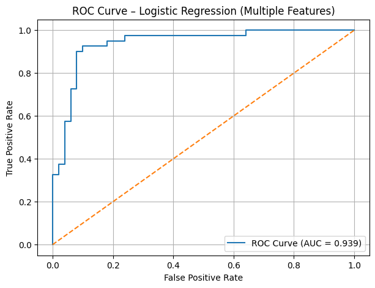

```python
from sklearn.metrics import roc_curve, auc
import matplotlib.pyplot as plt

# Predict probabilities for positive class
y_prob = best_model.predict_proba(X_test)[:, 1]

# ROC curve values
fpr, tpr, thresholds = roc_curve(y_test, y_prob)
roc_auc = auc(fpr, tpr)

# Plot ROC curve
plt.figure(figsize=(7,5))
plt.plot(fpr, tpr, label=f"ROC Curve (AUC = {roc_auc:.3f})")
plt.plot([0, 1], [0, 1], linestyle="--")
plt.xlabel("False Positive Rate")
plt.ylabel("True Positive Rate")
plt.title("ROC Curve – Logistic Regression (Multiple Features)")
plt.legend()
plt.grid(True)
plt.show()
```

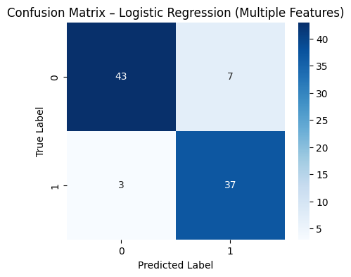

```python
import seaborn as sns

cm = confusion_matrix(y_test, y_pred)

plt.figure(figsize=(5,4))
sns.heatmap(cm, annot=True, fmt="d", cmap="Blues")
plt.xlabel("Predicted Label")
plt.ylabel("True Label")
plt.title("Confusion Matrix – Logistic Regression (Multiple Features)")
plt.show()
```

```python
# Get feature names
feature_names = df.drop("Heart Disease", axis=1).columns

# Get coefficients
coefficients = best_model.coef_[0]

# Create DataFrame
coef_df = pd.DataFrame({
    "Feature": feature_names,
    "Coefficient": coefficients
}).sort_values(by="Coefficient", ascending=False)

coef_df
```

|  | Feature | Coefficient |
| --- | --- | --- |
| 11 | Number of vessels fluro | 0.651481 |
| 1 | Sex | 0.533783 |
| 2 | Chest pain type | 0.481689 |
| 12 | Thallium | 0.431356 |
| 8 | Exercise angina | 0.281466 |
| 9 | ST depression | 0.251040 |
| 10 | Slope of ST | 0.250653 |
| 3 | BP | 0.155202 |
| 4 | Cholesterol | 0.145982 |
| 6 | EKG results | 0.091567 |
| 0 | Age | 0.042866 |
| 5 | FBS over 120 | -0.156523 |
| 7 | Max HR | -0.319385 |

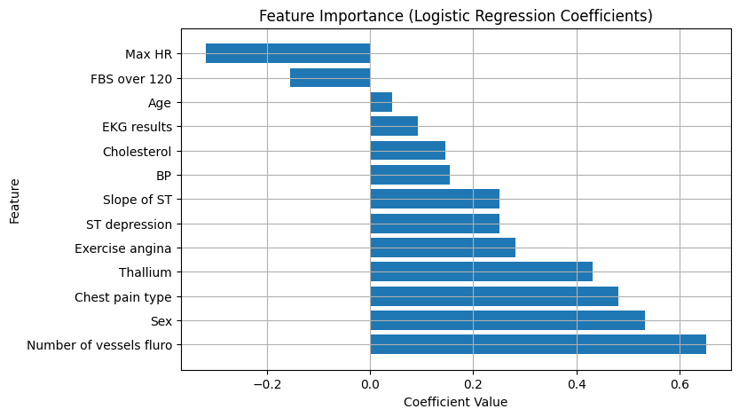

```python
plt.figure(figsize=(8,5))
plt.barh(coef_df["Feature"], coef_df["Coefficient"])
plt.xlabel("Coefficient Value")
plt.ylabel("Feature")
plt.title("Feature Importance (Logistic Regression Coefficients)")
plt.grid(True)
plt.show()
```

Purpose of the various graphs that are used in Logistic Regression

Logistic Regression uses a variety of graphs, i.e., curves and plots in order to explain how it works and how well it performs. Some of them are explained as follows:

1. Sigmoid curve: It shows how the model converts input values into probabilities between 0 and 1. Unlike the perceptron, Logistic Regression does not make hard decisions; instead, it gives smooth probability outputs.
2. Decision boundary: It is the point where the predicted probability reaches a chosen threshold (usually 0.5). It shows how the model separates one class from another.
3. ROC curve: It measures performance at all possible thresholds by comparing the True Positive Rate with the False Positive Rate. This gives a broader view of the model's behavior than using a single threshold.
4. AUC score: It summarizes the ROC curve into one value. A higher AUC means the model is better at distinguishing between the two classes.
5. Confusion matrix: It shows how many predictions are correct and incorrect, helping identify where the model makes mistakes.
6. Feature coefficient plot: It explains how each feature affects the prediction. Positive values increase the chance of the positive class, while negative values decrease it.

Discussion

In this lab, we applied Logistic Regression to a heart disease dataset to understand the machine learning pipeline. The experiment was divided into two tasks: training the model using a single feature and using multiple features.

In Task 1, only Cholesterol was used as the input feature. The sigmoid function showed how the model converts inputs into probability values. However, using a single feature provided limited information, which caused overlapping classes and poor prediction performance.

In Task 2, multiple features were used, which significantly improved classification. Since the decision boundary could not be visualized, the model was evaluated using metrics such as the confusion matrix and ROC curve. GridSearchCV, which is a method used to automatically find the best combination of hyperparameters by performing cross-validation over a predefined grid, was applied to improve model generalization. Feature coefficients were also analyzed to understand the influence of each feature.

Conclusion

The results showed that the multi-feature model performed better than the single-feature model. This lab demonstrated the importance of using multiple features and tuning hyperparameters using GridSearchCV for building reliable medical prediction models.